# Name: Placido Pereira

# Course: Msc. Data Science AI and Digital Buisness

# module: M504B AI and Applications

# GH No.: GH1043344

# Introduction

The hotel industry has a background, including the significance of making data-driven decisions. Hotel business is very dynamic and competitive. Informed decisions are becoming more and more imperative in success in such an environment. The development of online booking systems and digital platforms has resulted in a data overload, and it is necessary to rely on data-driven strategies as a competitive benefit. This project is intended to use this data to gain actionable information on the hotel booking demand.

The aim of the project is to examine a detailed hotel reservation dataset in order to draw major trends and patterns. With the use of data science, the analysis will help show factors that drive booking demand, cancellation, and customer behavior. The insights would assist the managers of the hotels to maximize their prices, marketing, and resource allocation strategies.

# Problem Statement

The need to analyze a comprehensive dataset of hotel booking that can be used to determine the key trends and patterns forms the problem statement of this project as it is stated in the Ai and Applications-IT_FINAL.docx file. The main problem is to bring data-supported information that may result in an improved business choice of hotel managers, like the pricing optimization, marketing, and resource distribution. The project will expose variables that affect the demand to make a booking, cancellation rate, and customer behavior.

## Import Libraries

```python
import pandas as pd
import numpy as np
import matplotlib.pyplot as plt
import seaborn as sns
```

```python
sns.set(style="whitegrid", palette="Set2")
```

# Data Source

https://www.kaggle.com/datasets/mojtaba142/hotel-booking?resource=download

## Data Exploration

It is Concerned with obtaining an initial idea of following of data prior to cleaning or analysis The following tasks are carried out by the notebook:

Loads the dataset file which contains Shows the initial few rows of the data to have an idea about the data.

Prints the form and content of the dataset, such as number of entries and columns, and type of data of each column.

Produces descriptive statistics of both numerical and categorical variables, taking an overview of the essential values, such as mean, standard deviation, and unique values.

Missing values in both columns that should be checked which is another essential step in data preprocessing.

```python
df = pd.read_csv('hotel_bookings.csv')
```

#### Display first few rows

```python
df.head()
```

|  | hotel | is_canceled | lead_time | arrival_date_year | arrival_date_month | arrival_date_week_number | arrival_date_day_of_month | stays_in_weekend_nights | stays_in_week_nights | adults | ... | deposit_type | agent | company | days_in_waiting_list | customer_type | adr | required_car_parking_spaces | total_of_special_requests | reservation_status | reservation_status_date |
| --- | --- | --- | --- | --- | --- | --- | --- | --- | --- | --- | --- | --- | --- | --- | --- | --- | --- | --- | --- | --- | --- |
| 0 | Resort Hotel | 0 | 342 | 2015 | July | 27 | 1 | 0 | 0 | 2 | ... | No Deposit | NaN | NaN | 0 | Transient | 0.0 | 0 | 0 | Check-Out | 2015-07-01 |
| 1 | Resort Hotel | 0 | 737 | 2015 | July | 27 | 1 | 0 | 0 | 2 | ... | No Deposit | NaN | NaN | 0 | Transient | 0.0 | 0 | 0 | Check-Out | 2015-07-01 |
| 2 | Resort Hotel | 0 | 7 | 2015 | July | 27 | 1 | 0 | 1 | 1 | ... | No Deposit | NaN | NaN | 0 | Transient | 75.0 | 0 | 0 | Check-Out | 2015-07-02 |
| 3 | Resort Hotel | 0 | 13 | 2015 | July | 27 | 1 | 0 | 1 | 1 | ... | No Deposit | 304.0 | NaN | 0 | Transient | 75.0 | 0 | 0 | Check-Out | 2015-07-02 |
| 4 | Resort Hotel | 0 | 14 | 2015 | July | 27 | 1 | 0 | 2 | 2 | ... | No Deposit | 240.0 | NaN | 0 | Transient | 98.0 | 0 | 1 | Check-Out | 2015-07-03 |

5 rows × 32 columns

```python
print("Dataset Shape:", df.shape)
```

```
Dataset Shape: (119390, 32)
```

```python
print("\nDataset Info:")
print(df.info())
```

```
Dataset Info:
<class 'pandas.core.frame.DataFrame'>
RangeIndex: 119390 entries, 0 to 119389
Data columns (total 32 columns):
 #   Column                          Non-Null Count   Dtype
---  ------                          --------------   -----
 0   hotel                           119390 non-null  object
 1   is_canceled                     119390 non-null  int64
 2   lead_time                       119390 non-null  int64
 3   arrival_date_year               119390 non-null  int64
 4   arrival_date_month              119390 non-null  object
 5   arrival_date_week_number        119390 non-null  int64
 6   arrival_date_day_of_month       119390 non-null  int64
 7   stays_in_weekend_nights         119390 non-null  int64
 8   stays_in_week_nights            119390 non-null  int64
```

[output cut: 26 more lines]

```python
print("\nDescriptive Statistics:")
display(df.describe(include="all"))
```

```
Descriptive Statistics:
```

|  | hotel | is_canceled | lead_time | arrival_date_year | arrival_date_month | arrival_date_week_number | arrival_date_day_of_month | stays_in_weekend_nights | stays_in_week_nights | adults | ... | deposit_type | agent | company | days_in_waiting_list | customer_type | adr | required_car_parking_spaces | total_of_special_requests | reservation_status | reservation_status_date |
| --- | --- | --- | --- | --- | --- | --- | --- | --- | --- | --- | --- | --- | --- | --- | --- | --- | --- | --- | --- | --- | --- |
| count | 119390 | 119390.000000 | 119390.000000 | 119390.000000 | 119390 | 119390.000000 | 119390.000000 | 119390.000000 | 119390.000000 | 119390.000000 | ... | 119390 | 103050.000000 | 6797.000000 | 119390.000000 | 119390 | 119390.000000 | 119390.000000 | 119390.000000 | 119390 | 119390 |
| unique | 2 | NaN | NaN | NaN | 12 | NaN | NaN | NaN | NaN | NaN | ... | 3 | NaN | NaN | NaN | 4 | NaN | NaN | NaN | 3 | 926 |
| top | City Hotel | NaN | NaN | NaN | August | NaN | NaN | NaN | NaN | NaN | ... | No Deposit | NaN | NaN | NaN | Transient | NaN | NaN | NaN | Check-Out | 2015-10-21 |
| freq | 79330 | NaN | NaN | NaN | 13877 | NaN | NaN | NaN | NaN | NaN | ... | 104641 | NaN | NaN | NaN | 89613 | NaN | NaN | NaN | 75166 | 1461 |
| mean | NaN | 0.370416 | 104.011416 | 2016.156554 | NaN | 27.165173 | 15.798241 | 0.927599 | 2.500302 | 1.856403 | ... | NaN | 86.693382 | 189.266735 | 2.321149 | NaN | 101.831122 | 0.062518 | 0.571363 | NaN | NaN |
| std | NaN | 0.482918 | 106.863097 | 0.707476 | NaN | 13.605138 | 8.780829 | 0.998613 | 1.908286 | 0.579261 | ... | NaN | 110.774548 | 131.655015 | 17.594721 | NaN | 50.535790 | 0.245291 | 0.792798 | NaN | NaN |
| min | NaN | 0.000000 | 0.000000 | 2015.000000 | NaN | 1.000000 | 1.000000 | 0.000000 | 0.000000 | 0.000000 | ... | NaN | 1.000000 | 6.000000 | 0.000000 | NaN | -6.380000 | 0.000000 | 0.000000 | NaN | NaN |
| 25% | NaN | 0.000000 | 18.000000 | 2016.000000 | NaN | 16.000000 | 8.000000 | 0.000000 | 1.000000 | 2.000000 | ... | NaN | 9.000000 | 62.000000 | 0.000000 | NaN | 69.290000 | 0.000000 | 0.000000 | NaN | NaN |
| 50% | NaN | 0.000000 | 69.000000 | 2016.000000 | NaN | 28.000000 | 16.000000 | 1.000000 | 2.000000 | 2.000000 | ... | NaN | 14.000000 | 179.000000 | 0.000000 | NaN | 94.575000 | 0.000000 | 0.000000 | NaN | NaN |
| 75% | NaN | 1.000000 | 160.000000 | 2017.000000 | NaN | 38.000000 | 23.000000 | 2.000000 | 3.000000 | 2.000000 | ... | NaN | 229.000000 | 270.000000 | 0.000000 | NaN | 126.000000 | 0.000000 | 1.000000 | NaN | NaN |
| max | NaN | 1.000000 | 737.000000 | 2017.000000 | NaN | 53.000000 | 31.000000 | 19.000000 | 50.000000 | 55.000000 | ... | NaN | 535.000000 | 543.000000 | 391.000000 | NaN | 5400.000000 | 8.000000 | 5.000000 | NaN | NaN |

11 rows × 32 columns

```python
df.isnull().sum()
```

```
hotel                                  0
is_canceled                            0
lead_time                              0
arrival_date_year                      0
arrival_date_month                     0
arrival_date_week_number               0
arrival_date_day_of_month              0
stays_in_weekend_nights                0
stays_in_week_nights                   0
adults                                 0
children                               4
babies                                 0
meal                                   0
country                              488
market_segment                         0
distribution_channel                   0
is_repeated_guest                      0
previous_cancellations                 0
previous_bookings_not_canceled         0
reserved_room_type                     0
assigned_room_type                     0
booking_changes                        0
deposit_type                           0
agent                              16340
company                           112593
days_in_waiting_list                   0
customer_type                          0
adr                                    0
required_car_parking_spaces            0
total_of_special_requests              0
reservation_status                     0
reservation_status_date                0
dtype: int64
```

```python
print("\nNumber of Duplicate Rows:", df.duplicated().sum())
```

```
Number of Duplicate Rows: 31994
```

## Data Preprocessing

The notebook standardizes the data to be analyzed by dealing with missing data and duplication of data, and by encoding the categorical variables. This helps to make sure that the dataset is clean and in an appropriate format to be further analyzed and modeled on.

```python
df['children'] = df['children'].fillna(df['children'].median())
df['country']  = df['country'].fillna("Unknown")
df['agent']    = df['agent'].fillna(0)
df['company']  = df['company'].fillna(0)
```

```python
print("\nMissing values after handling:")
print(df.isnull().sum())
```

```
Missing values after handling:
hotel                             0
is_canceled                       0
lead_time                         0
arrival_date_year                 0
arrival_date_month                0
arrival_date_week_number          0
arrival_date_day_of_month         0
stays_in_weekend_nights           0
stays_in_week_nights              0
adults                            0
children                          0
babies                            0
meal                              0
country                           0
market_segment                    0
distribution_channel              0
is_repeated_guest                 0
previous_cancellations            0
previous_bookings_not_canceled    0
reserved_room_type                0
assigned_room_type                0
booking_changes                   0
deposit_type                      0
agent                             0
company                           0
days_in_waiting_list              0
customer_type                     0
adr                               0
required_car_parking_spaces       0
total_of_special_requests         0
reservation_status                0
reservation_status_date           0
dtype: int64
```

```python
print("\nDuplicate Rows Before Removal:", df.duplicated().sum())
df = df.drop_duplicates()
print("Duplicate Rows After Removal:", df.duplicated().sum())
```

```
Duplicate Rows Before Removal: 31994
Duplicate Rows After Removal: 0
```

#### Encode Categorical Variables

The step is necessary in the preparation of the dataset to ML models. Numbers are interpreted by computers and therefore, it is necessary to encode categorical variables (such as hoteltype, country, or mealtype) into numerical format. This is probably done through methods such as one-hot encoding or label encoding in the notebook, and therefore the data can be analyzed and modeled.

```python
df_encoded = df.copy()
df_encoded = pd.get_dummies(df_encoded,
                            columns=['hotel', 'meal', 'market_segment',
                                     'distribution_channel', 'reserved_room_type',
                                     'assigned_room_type', 'deposit_type',
                                     'customer_type', 'reservation_status'],
                            drop_first=True)

print("\nEncoded Dataset Shape:", df_encoded.shape)
```

```
Encoded Dataset Shape: (87396, 66)
```

### Final Dataset Preview

A preview of the dataset once all the data cleaning and preprocessing processes are done. This preview is important to ensure that the dataset can used in the EDA and other ML processes. It validates that the missing values are addressed, the duplicated values have been eliminated, and the categoricals have been successfully coded.

```python
display(df_encoded.head())
```

|  | is_canceled | lead_time | arrival_date_year | arrival_date_month | arrival_date_week_number | arrival_date_day_of_month | stays_in_weekend_nights | stays_in_week_nights | adults | children | ... | assigned_room_type_K | assigned_room_type_L | assigned_room_type_P | deposit_type_Non Refund | deposit_type_Refundable | customer_type_Group | customer_type_Transient | customer_type_Transient-Party | reservation_status_Check-Out | reservation_status_No-Show |
| --- | --- | --- | --- | --- | --- | --- | --- | --- | --- | --- | --- | --- | --- | --- | --- | --- | --- | --- | --- | --- | --- |
| 0 | 0 | 342 | 2015 | July | 27 | 1 | 0 | 0 | 2 | 0.0 | ... | False | False | False | False | False | False | True | False | True | False |
| 1 | 0 | 737 | 2015 | July | 27 | 1 | 0 | 0 | 2 | 0.0 | ... | False | False | False | False | False | False | True | False | True | False |
| 2 | 0 | 7 | 2015 | July | 27 | 1 | 0 | 1 | 1 | 0.0 | ... | False | False | False | False | False | False | True | False | True | False |
| 3 | 0 | 13 | 2015 | July | 27 | 1 | 0 | 1 | 1 | 0.0 | ... | False | False | False | False | False | False | True | False | True | False |
| 4 | 0 | 14 | 2015 | July | 27 | 1 | 0 | 2 | 2 | 0.0 | ... | False | False | False | False | False | False | True | False | True | False |

5 rows × 66 columns

## Explanatory Data Analysis (EDA)

```python
def add_labels(ax, fmt="{:.0f}"):
    for p in ax.patches:
        height = p.get_height()
        if not np.isnan(height):
            ax.annotate(fmt.format(height),
                        (p.get_x() + p.get_width() / 2., height),
                        ha='center', va='bottom', fontsize=9, rotation=0)
```

### Q1. Cancellation rate

The calculation of the total cancellation rate takes place in this part of the notebook, It establishes the percentage of canceled hotel bookings. This analysis is one of the key performance indicators (KPI) and it gives a base insight into the customer behavior.

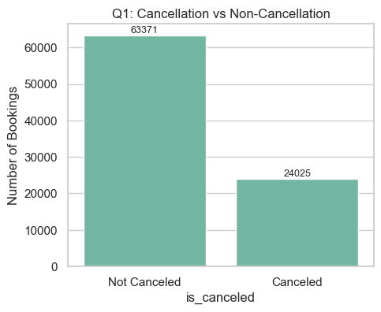

```python
plt.figure(figsize=(5,4))
ax = sns.countplot(x="is_canceled", data=df)
plt.title("Q1: Cancellation vs Non-Cancellation")
plt.xticks([0,1], ["Not Canceled", "Canceled"])
plt.ylabel("Number of Bookings")
add_labels(ax)
plt.show()
```

### Q2. Bookings per hotel type

Here it's comparing how bookings are distributed among the various types of hotels, like Resort Hotel and City Hotel. The analysis contributes to the realization of the type of hotel that is more popular among the guests.

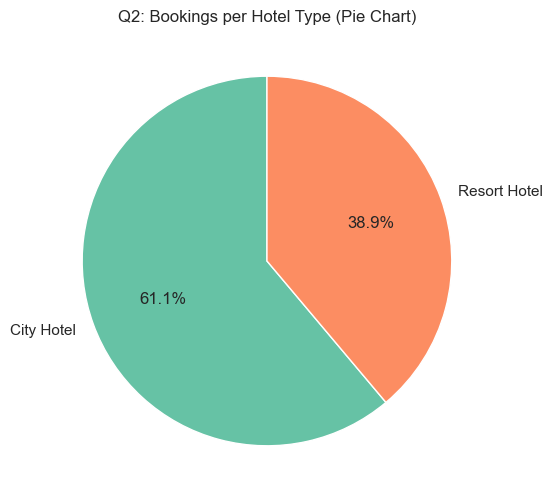

```python
plt.figure(figsize=(6,6))
hotel_counts = df['hotel'].value_counts()

# Pie chart
plt.pie(hotel_counts,
        labels=hotel_counts.index,
        autopct='%1.1f%%',
        startangle=90,
        colors=sns.color_palette("Set2"))

plt.title("Q2: Bookings per Hotel Type (Pie Chart)")
plt.show()
```

### Q3. Top 5 countries by bookings

Here it determines the top 5 countries of origin of bookings. The marketing and strategy In this analysis, it is useful because a hotel can focus its marketing campaigns on the major markets.

```python
top_country = df['country'].value_counts().head(5)
```

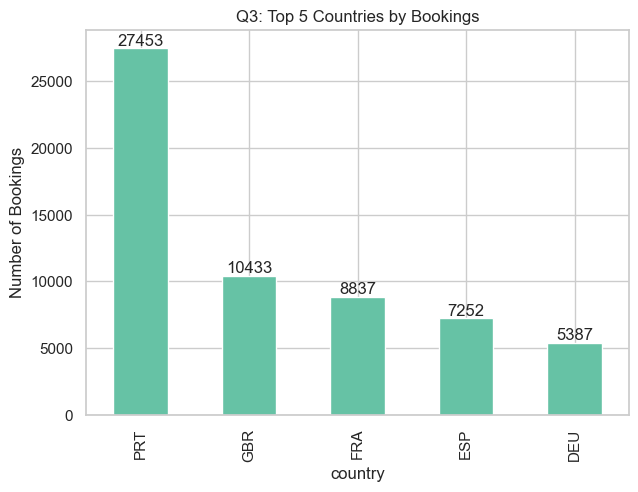

```python
plt.figure(figsize=(7,5))
ax = top_country.plot(kind="bar")
plt.title("Q3: Top 5 Countries by Bookings")
plt.ylabel("Number of Bookings")
for p in ax.patches:
    ax.annotate(str(int(p.get_height())),
                (p.get_x() + p.get_width()/2., p.get_height()),
                ha='center', va='bottom')
plt.show()
```

### Q4. ADR distribution

Here it is a visualization of the distribution of the Average Daily Rate (ADR). One of the revenue indicators in the hotel business is ADR. The distribution analysis assists in pricing policies and expenditure behaviours of guests.

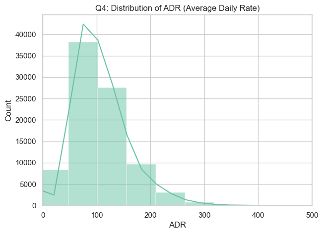

```python
plt.figure(figsize=(7,5))
sns.histplot(df['adr'], bins=100, kde=True)
plt.title("Q4: Distribution of ADR (Average Daily Rate)")
plt.xlabel("ADR")
plt.xlim(0, 500)
plt.show()
```

### Q5. Monthly bookings

it depicts the trend in bookings during the various months. This time-series analysis shows the seasonal trends and assists in predicting demand and allocating resources respectively.

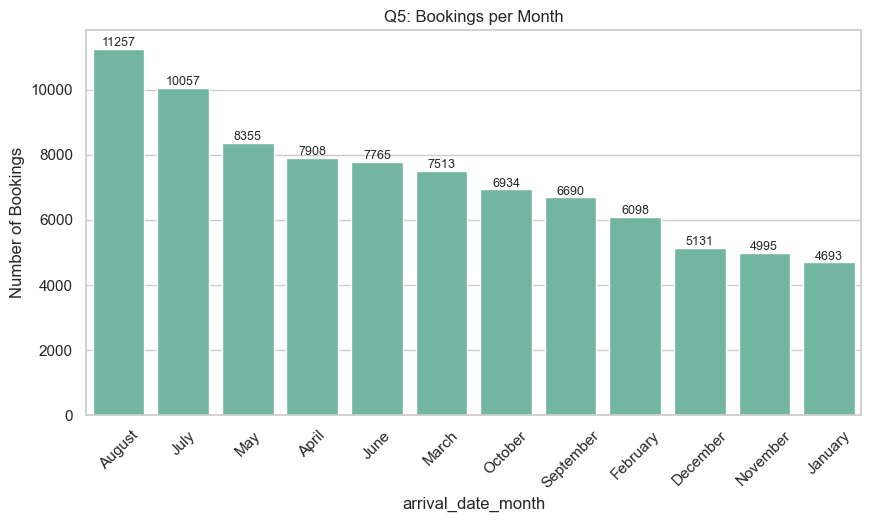

```python
plt.figure(figsize=(10,5))
ax = sns.countplot(x="arrival_date_month", data=df,
                   order=df['arrival_date_month'].value_counts().index)
plt.title("Q5: Bookings per Month")
plt.xticks(rotation=45)
plt.ylabel("Number of Bookings")
add_labels(ax)
plt.show()
```

## Q6. Cancellation rate by repeated guest

it explores the connection between the number of cancellations and the repeat customer status of the guest. It can also give the information about customer loyalty and aid in creating the strategy of minimizing cancellations.

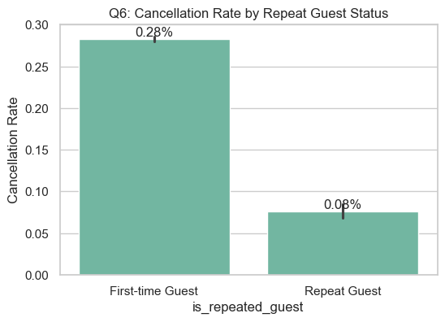

```python
plt.figure(figsize=(6,4))
ax = sns.barplot(x="is_repeated_guest", y="is_canceled", data=df)
plt.title("Q6: Cancellation Rate by Repeat Guest Status")
plt.xticks([0,1], ["First-time Guest", "Repeat Guest"])
plt.ylabel("Cancellation Rate")
for p in ax.patches:
    height = p.get_height()
    ax.annotate(f"{height:.2f}%",
                (p.get_x() + p.get_width()/2., height),
                ha='center', va='bottom')
plt.show()
```